# EDA on IPL data TSF

**DATA SCIENCE AND BUSINESS ANALYTICS INTERN AT THE SPARKS FOUNDATION**

**#GRIPMAY23**

**NAME: ARABATI PRANAWI**

**Task #5 : Exploratory Data Analysis - Sports (IPL)** **Level - Advanced**

**Dataset** :https://bit.ly/34SRn3b

```python
import numpy as np
import pandas as pd
import matplotlib.pyplot as plt
import seaborn as sns
%matplotlib inline
import warnings
warnings.filterwarnings('ignore')
```

```python
match = pd.read_csv('matches.csv')
```

```python
deliveries = pd.read_csv('deliveries.csv')
```

```python
match.head(5)
```

|  | id | season | city | date | team1 | team2 | toss_winner | toss_decision | result | dl_applied | winner | win_by_runs | win_by_wickets | player_of_match | venue | umpire1 | umpire2 | umpire3 |
| --- | --- | --- | --- | --- | --- | --- | --- | --- | --- | --- | --- | --- | --- | --- | --- | --- | --- | --- |
| 0 | 1 | 2017 | Hyderabad | 2017-04-05 | Sunrisers Hyderabad | Royal Challengers Bangalore | Royal Challengers Bangalore | field | normal | 0 | Sunrisers Hyderabad | 35 | 0 | Yuvraj Singh | Rajiv Gandhi International Stadium, Uppal | AY Dandekar | NJ Llong | NaN |
| 1 | 2 | 2017 | Pune | 2017-04-06 | Mumbai Indians | Rising Pune Supergiant | Rising Pune Supergiant | field | normal | 0 | Rising Pune Supergiant | 0 | 7 | SPD Smith | Maharashtra Cricket Association Stadium | A Nand Kishore | S Ravi | NaN |
| 2 | 3 | 2017 | Rajkot | 2017-04-07 | Gujarat Lions | Kolkata Knight Riders | Kolkata Knight Riders | field | normal | 0 | Kolkata Knight Riders | 0 | 10 | CA Lynn | Saurashtra Cricket Association Stadium | Nitin Menon | CK Nandan | NaN |
| 3 | 4 | 2017 | Indore | 2017-04-08 | Rising Pune Supergiant | Kings XI Punjab | Kings XI Punjab | field | normal | 0 | Kings XI Punjab | 0 | 6 | GJ Maxwell | Holkar Cricket Stadium | AK Chaudhary | C Shamshuddin | NaN |
| 4 | 5 | 2017 | Bangalore | 2017-04-08 | Royal Challengers Bangalore | Delhi Daredevils | Royal Challengers Bangalore | bat | normal | 0 | Royal Challengers Bangalore | 15 | 0 | KM Jadhav | M Chinnaswamy Stadium | NaN | NaN | NaN |

```python
match.tail(5)
```

|  | id | season | city | date | team1 | team2 | toss_winner | toss_decision | result | dl_applied | winner | win_by_runs | win_by_wickets | player_of_match | venue | umpire1 | umpire2 | umpire3 |
| --- | --- | --- | --- | --- | --- | --- | --- | --- | --- | --- | --- | --- | --- | --- | --- | --- | --- | --- |
| 751 | 11347 | 2019 | Mumbai | 05/05/19 | Kolkata Knight Riders | Mumbai Indians | Mumbai Indians | field | normal | 0 | Mumbai Indians | 0 | 9 | HH Pandya | Wankhede Stadium | Nanda Kishore | O Nandan | S Ravi |
| 752 | 11412 | 2019 | Chennai | 07/05/19 | Chennai Super Kings | Mumbai Indians | Chennai Super Kings | bat | normal | 0 | Mumbai Indians | 0 | 6 | AS Yadav | M. A. Chidambaram Stadium | Nigel Llong | Nitin Menon | Ian Gould |
| 753 | 11413 | 2019 | Visakhapatnam | 08/05/19 | Sunrisers Hyderabad | Delhi Capitals | Delhi Capitals | field | normal | 0 | Delhi Capitals | 0 | 2 | RR Pant | ACA-VDCA Stadium | NaN | NaN | NaN |
| 754 | 11414 | 2019 | Visakhapatnam | 10/05/19 | Delhi Capitals | Chennai Super Kings | Chennai Super Kings | field | normal | 0 | Chennai Super Kings | 0 | 6 | F du Plessis | ACA-VDCA Stadium | Sundaram Ravi | Bruce Oxenford | Chettithody Shamshuddin |
| 755 | 11415 | 2019 | Hyderabad | 12/05/19 | Mumbai Indians | Chennai Super Kings | Mumbai Indians | bat | normal | 0 | Mumbai Indians | 1 | 0 | JJ Bumrah | Rajiv Gandhi Intl. Cricket Stadium | Nitin Menon | Ian Gould | Nigel Llong |

```python
#Number of rows and columns
match.shape
```

```
(756, 18)
```

```python
deliveries.shape
```

```
(179078, 21)
```

```python
deliveries.head(5)
```

|  | match_id | inning | batting_team | bowling_team | over | ball | batsman | non_striker | bowler | is_super_over | ... | bye_runs | legbye_runs | noball_runs | penalty_runs | batsman_runs | extra_runs | total_runs | player_dismissed | dismissal_kind | fielder |
| --- | --- | --- | --- | --- | --- | --- | --- | --- | --- | --- | --- | --- | --- | --- | --- | --- | --- | --- | --- | --- | --- |
| 0 | 1 | 1 | Sunrisers Hyderabad | Royal Challengers Bangalore | 1 | 1 | DA Warner | S Dhawan | TS Mills | 0 | ... | 0 | 0 | 0 | 0 | 0 | 0 | 0 | NaN | NaN | NaN |
| 1 | 1 | 1 | Sunrisers Hyderabad | Royal Challengers Bangalore | 1 | 2 | DA Warner | S Dhawan | TS Mills | 0 | ... | 0 | 0 | 0 | 0 | 0 | 0 | 0 | NaN | NaN | NaN |
| 2 | 1 | 1 | Sunrisers Hyderabad | Royal Challengers Bangalore | 1 | 3 | DA Warner | S Dhawan | TS Mills | 0 | ... | 0 | 0 | 0 | 0 | 4 | 0 | 4 | NaN | NaN | NaN |
| 3 | 1 | 1 | Sunrisers Hyderabad | Royal Challengers Bangalore | 1 | 4 | DA Warner | S Dhawan | TS Mills | 0 | ... | 0 | 0 | 0 | 0 | 0 | 0 | 0 | NaN | NaN | NaN |
| 4 | 1 | 1 | Sunrisers Hyderabad | Royal Challengers Bangalore | 1 | 5 | DA Warner | S Dhawan | TS Mills | 0 | ... | 0 | 0 | 0 | 0 | 0 | 2 | 2 | NaN | NaN | NaN |

5 rows × 21 columns

```python
match.info()
```

```
<class 'pandas.core.frame.DataFrame'>
RangeIndex: 756 entries, 0 to 755
Data columns (total 18 columns):
 #   Column           Non-Null Count  Dtype
---  ------           --------------  -----
 0   id               756 non-null    int64
 1   season           756 non-null    int64
 2   city             749 non-null    object
 3   date             756 non-null    object
 4   team1            756 non-null    object
 5   team2            756 non-null    object
 6   toss_winner      756 non-null    object
 7   toss_decision    756 non-null    object
 8   result           756 non-null    object
 9   dl_applied       756 non-null    int64
 10  winner           752 non-null    object
 11  win_by_runs      756 non-null    int64
 12  win_by_wickets   756 non-null    int64
 13  player_of_match  752 non-null    object
 14  venue            756 non-null    object
 15  umpire1          754 non-null    object
 16  umpire2          754 non-null    object
 17  umpire3          119 non-null    object
dtypes: int64(5), object(13)
memory usage: 106.4+ KB
```

```python
deliveries.info()
```

```
<class 'pandas.core.frame.DataFrame'>
RangeIndex: 179078 entries, 0 to 179077
Data columns (total 21 columns):
 #   Column            Non-Null Count   Dtype
---  ------            --------------   -----
 0   match_id          179078 non-null  int64
 1   inning            179078 non-null  int64
 2   batting_team      179078 non-null  object
 3   bowling_team      179078 non-null  object
 4   over              179078 non-null  int64
 5   ball              179078 non-null  int64
 6   batsman           179078 non-null  object
 7   non_striker       179078 non-null  object
 8   bowler            179078 non-null  object
 9   is_super_over     179078 non-null  int64
 10  wide_runs         179078 non-null  int64
 11  bye_runs          179078 non-null  int64
 12  legbye_runs       179078 non-null  int64
 13  noball_runs       179078 non-null  int64
 14  penalty_runs      179078 non-null  int64
 15  batsman_runs      179078 non-null  int64
 16  extra_runs        179078 non-null  int64
 17  total_runs        179078 non-null  int64
 18  player_dismissed  8834 non-null    object
 19  dismissal_kind    8834 non-null    object
 20  fielder           6448 non-null    object
dtypes: int64(13), object(8)
memory usage: 28.7+ MB
```

```python
#statistical summary
match.describe()
```

|  | id | season | dl_applied | win_by_runs | win_by_wickets |
| --- | --- | --- | --- | --- | --- |
| count | 756.000000 | 756.000000 | 756.000000 | 756.000000 | 756.000000 |
| mean | 1792.178571 | 2013.444444 | 0.025132 | 13.283069 | 3.350529 |
| std | 3464.478148 | 3.366895 | 0.156630 | 23.471144 | 3.387963 |
| min | 1.000000 | 2008.000000 | 0.000000 | 0.000000 | 0.000000 |
| 25% | 189.750000 | 2011.000000 | 0.000000 | 0.000000 | 0.000000 |
| 50% | 378.500000 | 2013.000000 | 0.000000 | 0.000000 | 4.000000 |
| 75% | 567.250000 | 2016.000000 | 0.000000 | 19.000000 | 6.000000 |
| max | 11415.000000 | 2019.000000 | 1.000000 | 146.000000 | 10.000000 |

```python
deliveries.describe()
```

|  | match_id | inning | over | ball | is_super_over | wide_runs | bye_runs | legbye_runs | noball_runs | penalty_runs | batsman_runs | extra_runs | total_runs |
| --- | --- | --- | --- | --- | --- | --- | --- | --- | --- | --- | --- | --- | --- |
| count | 179078.000000 | 179078.000000 | 179078.000000 | 179078.000000 | 179078.000000 | 179078.000000 | 179078.000000 | 179078.000000 | 179078.000000 | 179078.000000 | 179078.000000 | 179078.000000 | 179078.000000 |
| mean | 1802.252957 | 1.482952 | 10.162488 | 3.615587 | 0.000452 | 0.036721 | 0.004936 | 0.021136 | 0.004183 | 0.000056 | 1.246864 | 0.067032 | 1.313897 |
| std | 3472.322805 | 0.502074 | 5.677684 | 1.806966 | 0.021263 | 0.251161 | 0.116480 | 0.194908 | 0.070492 | 0.016709 | 1.608270 | 0.342553 | 1.605422 |
| min | 1.000000 | 1.000000 | 1.000000 | 1.000000 | 0.000000 | 0.000000 | 0.000000 | 0.000000 | 0.000000 | 0.000000 | 0.000000 | 0.000000 | 0.000000 |
| 25% | 190.000000 | 1.000000 | 5.000000 | 2.000000 | 0.000000 | 0.000000 | 0.000000 | 0.000000 | 0.000000 | 0.000000 | 0.000000 | 0.000000 | 0.000000 |
| 50% | 379.000000 | 1.000000 | 10.000000 | 4.000000 | 0.000000 | 0.000000 | 0.000000 | 0.000000 | 0.000000 | 0.000000 | 1.000000 | 0.000000 | 1.000000 |
| 75% | 567.000000 | 2.000000 | 15.000000 | 5.000000 | 0.000000 | 0.000000 | 0.000000 | 0.000000 | 0.000000 | 0.000000 | 1.000000 | 0.000000 | 1.000000 |
| max | 11415.000000 | 5.000000 | 20.000000 | 9.000000 | 1.000000 | 5.000000 | 4.000000 | 5.000000 | 5.000000 | 5.000000 | 7.000000 | 7.000000 | 10.000000 |

```python
match.isnull().sum()
```

```
id                   0
season               0
city                 7
date                 0
team1                0
team2                0
toss_winner          0
toss_decision        0
result               0
dl_applied           0
winner               4
win_by_runs          0
win_by_wickets       0
player_of_match      4
venue                0
umpire1              2
umpire2              2
umpire3            637
dtype: int64
```

```python
deliveries.isnull().sum()
```

```
match_id                 0
inning                   0
batting_team             0
bowling_team             0
over                     0
ball                     0
batsman                  0
non_striker              0
bowler                   0
is_super_over            0
wide_runs                0
bye_runs                 0
legbye_runs              0
noball_runs              0
penalty_runs             0
batsman_runs             0
extra_runs               0
total_runs               0
player_dismissed    170244
dismissal_kind      170244
fielder             172630
dtype: int64
```

```python
#dropping irrelevant columns
match_1 = match.drop(columns=['umpire3'],axis = 1)
```

```python
match_1.shape
```

```
(756, 17)
```

```python
match_1.isnull().sum()
```

```
id                 0
season             0
city               7
date               0
team1              0
team2              0
toss_winner        0
toss_decision      0
result             0
dl_applied         0
winner             4
win_by_runs        0
win_by_wickets     0
player_of_match    4
venue              0
umpire1            2
umpire2            2
dtype: int64
```

```python
match_1.info()
```

```
<class 'pandas.core.frame.DataFrame'>
RangeIndex: 756 entries, 0 to 755
Data columns (total 17 columns):
 #   Column           Non-Null Count  Dtype
---  ------           --------------  -----
 0   id               756 non-null    int64
 1   season           756 non-null    int64
 2   city             749 non-null    object
 3   date             756 non-null    object
 4   team1            756 non-null    object
 5   team2            756 non-null    object
 6   toss_winner      756 non-null    object
 7   toss_decision    756 non-null    object
 8   result           756 non-null    object
 9   dl_applied       756 non-null    int64
 10  winner           752 non-null    object
 11  win_by_runs      756 non-null    int64
 12  win_by_wickets   756 non-null    int64
 13  player_of_match  752 non-null    object
 14  venue            756 non-null    object
 15  umpire1          754 non-null    object
 16  umpire2          754 non-null    object
dtypes: int64(5), object(12)
memory usage: 100.5+ KB
```

```python
match_1.columns.values
```

```
array(['id', 'season', 'city', 'date', 'team1', 'team2', 'toss_winner',
       'toss_decision', 'result', 'dl_applied', 'winner', 'win_by_runs',
       'win_by_wickets', 'player_of_match', 'venue', 'umpire1', 'umpire2'],
      dtype=object)
```

```python
match_1['season'].unique()
```

```
array([2017, 2008, 2009, 2010, 2011, 2012, 2013, 2014, 2015, 2016, 2018,
       2019], dtype=int64)
```

```python
wins_per_season = match_1.groupby("season")["winner"].value_counts()
```

```python
wins_per_season
```

```
season  winner
2008    Rajasthan Royals               13
        Kings XI Punjab                10
        Chennai Super Kings             9
        Delhi Daredevils                7
        Mumbai Indians                  7
                                       ..
2019    Kings XI Punjab                 6
        Kolkata Knight Riders           6
        Sunrisers Hyderabad             6
        Rajasthan Royals                5
        Royal Challengers Bangalore     5
Name: winner, Length: 100, dtype: int64
```

```python
wins_per_season.head(5)
```

```
season  winner
2008    Rajasthan Royals       13
        Kings XI Punjab        10
        Chennai Super Kings     9
        Delhi Daredevils        7
        Mumbai Indians          7
Name: winner, dtype: int64
```

**Team won by Maximum Runs**

```python
match_1.iloc[match_1['win_by_runs'].idxmax()]
```

```
id                               44
season                         2017
city                          Delhi
date                     2017-05-06
team1                Mumbai Indians
team2              Delhi Daredevils
toss_winner        Delhi Daredevils
toss_decision                 field
result                       normal
dl_applied                        0
winner               Mumbai Indians
win_by_runs                     146
win_by_wickets                    0
player_of_match         LMP Simmons
venue              Feroz Shah Kotla
umpire1                 Nitin Menon
umpire2                   CK Nandan
Name: 43, dtype: object
```

**Team won by Maximum Wickets**

```python
match_1.iloc[match_1['win_by_wickets'].idxmax()]['winner']
```

```
'Kolkata Knight Riders'
```

**Team won by Minimum Runs**

```python
match_1.iloc[match_1[match_1['win_by_runs'].ge(1)].win_by_runs.idxmin()]['winner']
```

```
'Mumbai Indians'
```

**Team won by Minimum wickets**

```python
match_1.iloc[match_1[match_1['win_by_wickets'].ge(1)].win_by_wickets.idxmin()]['winner']
```

```
'Kolkata Knight Riders'
```

```python
match_1.iloc[match_1[match_1['win_by_wickets'].ge(1)].win_by_wickets.idxmin()]
```

```
id                                   560
season                              2015
city                             Kolkata
date                          2015-05-09
team1                    Kings XI Punjab
team2              Kolkata Knight Riders
toss_winner              Kings XI Punjab
toss_decision                        bat
result                            normal
dl_applied                             0
winner             Kolkata Knight Riders
win_by_runs                            0
win_by_wickets                         1
player_of_match               AD Russell
venue                       Eden Gardens
umpire1                     AK Chaudhary
umpire2                  HDPK Dharmasena
Name: 559, dtype: object
```

**Season which had most number of Matches**

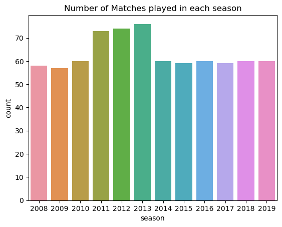

```python
#countplot
sns.countplot(x = match_1['season'])
plt.title('Number of Matches played in each season')
plt.show()
```

**Number of matches won by each team**

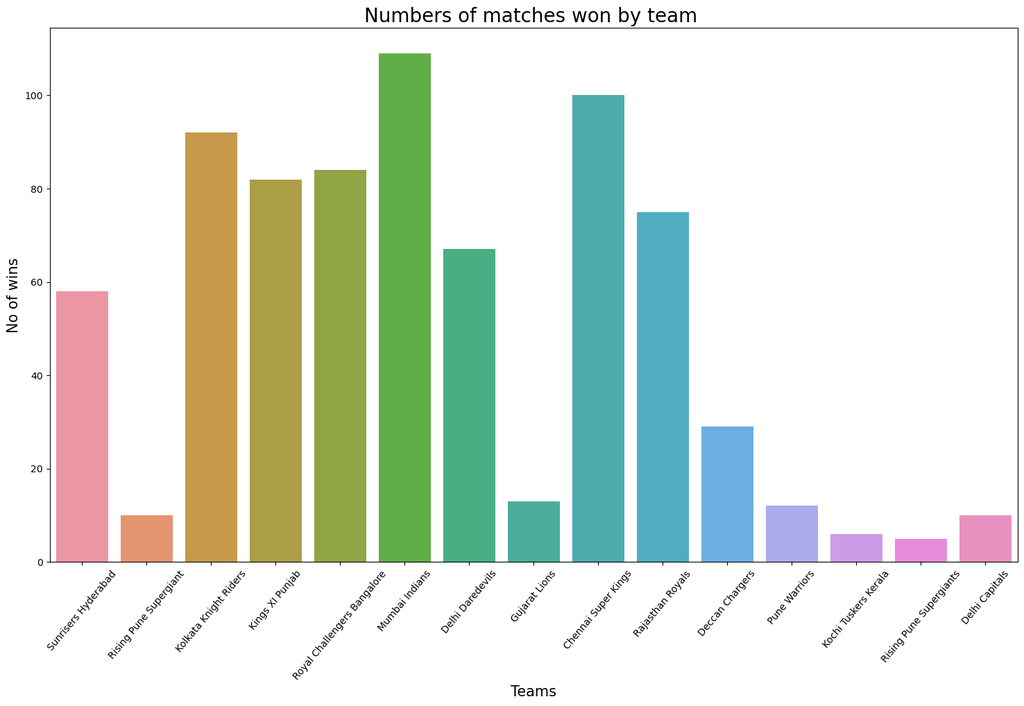

```python
plt.figure(figsize = (18,10))
sns.countplot(x='winner',data=match_1)
plt.title("Numbers of matches won by team ",fontsize=20)
plt.xticks(rotation=50)
plt.xlabel("Teams",fontsize=15)
plt.ylabel("No of wins",fontsize=15)
plt.show()
```

**Number of matches in Each Venue**

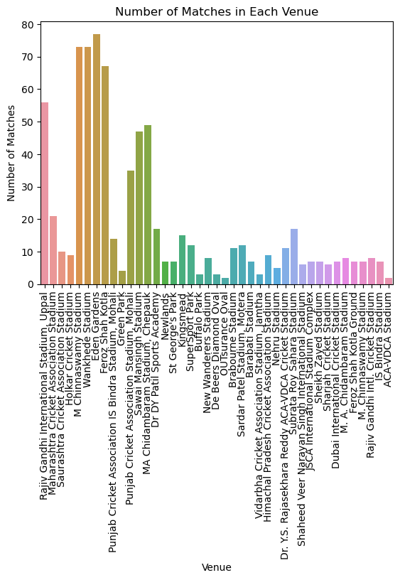

```python
sns.countplot(x='venue',data=match_1)
plt.title('Number of Matches in Each Venue')
plt.xticks(rotation='vertical')
plt.xlabel('Venue')
plt.ylabel('Number of Matches')
plt.show()
```

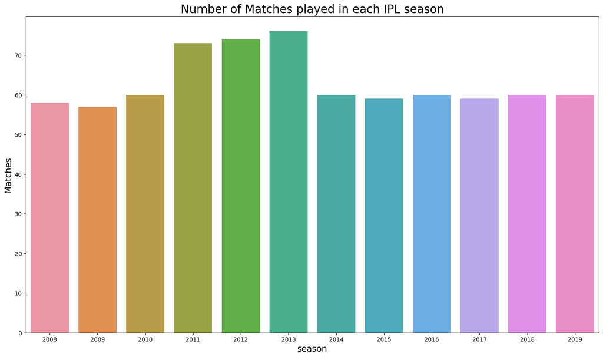

```python
plt.figure(figsize = (18,10))
sns.countplot('season',data=match_1)
plt.title("Number of Matches played in each IPL season",fontsize=20)
plt.xlabel("season",fontsize=15)
plt.ylabel('Matches',fontsize=15)
plt.show()
```

**Toss Decision**

```python
match_1['win_by']=np.where(match_1['win_by_runs']>0,'Bat first','Bowl first')
```

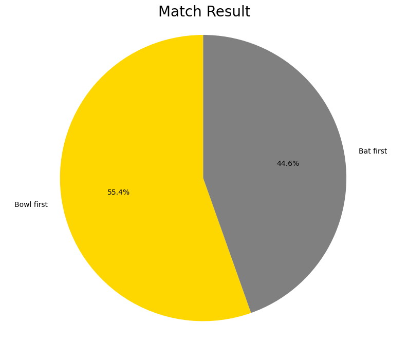

```python
Win=match_1.win_by.value_counts()
labels=np.array(Win.index)
sizes = Win.values
colors = ['Gold', 'grey']
plt.figure(figsize = (10,8))
plt.pie(sizes, labels=labels, colors=colors,
autopct='%1.1f%%',startangle=90)
plt.title('Match Result',fontsize=20)
plt.axis('equal')
plt.show()
```

**Number of matches won by batting first and bowling first**

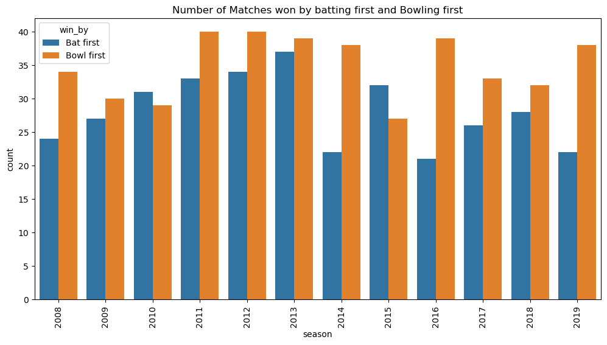

```python
plt.figure(figsize=(12,6))
sns.countplot(x='season', hue='win_by', data=match_1)
plt.xticks(rotation='vertical')
plt.title('Number of Matches won by batting first and Bowling first')
plt.show()
```

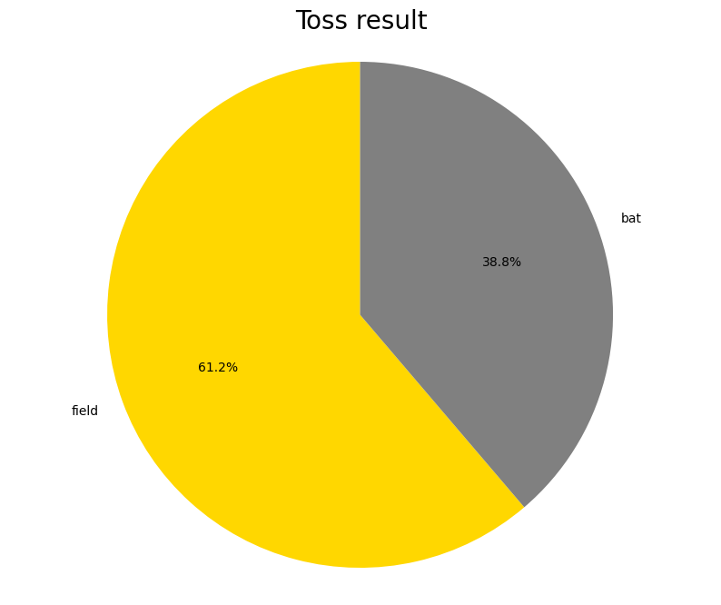

```python
Toss=match_1.toss_decision.value_counts()
labels=np.array(Toss.index)
sizes = Toss.values
colors = ['Gold','Grey']
plt.figure(figsize = (10,8))
plt.pie(sizes, labels=labels, colors=colors,
autopct='%1.1f%%',startangle=90)
plt.title('Toss result',fontsize=20)
plt.axis('equal')
plt.show()
```

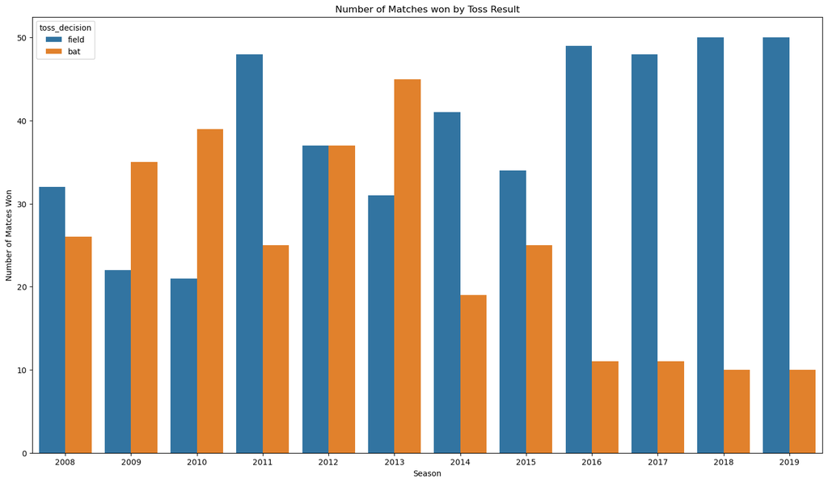

```python
# countplot on number of matches won on toss decision
plt.figure(figsize=(18,10))
sns.countplot(x = 'season',hue= 'toss_decision',data= match_1)
plt.title('Number of Matches won by Toss Result')
plt.xlabel('Season')
plt.ylabel('Number of Matces Won')
plt.show()
```

**Champions in Each Season**

```python
champ=match_1.drop_duplicates(subset=['season'], keep='last')
champ[['season','winner']].reset_index(drop=True).sort_values('season')
```

|  | season | winner |
| --- | --- | --- |
| 1 | 2008 | Rajasthan Royals |
| 2 | 2009 | Deccan Chargers |
| 3 | 2010 | Chennai Super Kings |
| 4 | 2011 | Chennai Super Kings |
| 5 | 2012 | Kolkata Knight Riders |
| 6 | 2013 | Mumbai Indians |
| 7 | 2014 | Kolkata Knight Riders |
| 8 | 2015 | Mumbai Indians |
| 9 | 2016 | Sunrisers Hyderabad |
| 0 | 2017 | Mumbai Indians |
| 10 | 2018 | Chennai Super Kings |
| 11 | 2019 | Mumbai Indians |

[figure not shown]

```python
match = champ.win_by.value_counts()
labels=np.array(Toss.index)
sizes = match.values
colors = ['gold', 'grey']
plt.figure(figsize = (10,8))
plt.pie(sizes, labels=labels, colors=colors,autopct='%1.1f%%',startangle=90)
plt.title('Match Result',fontsize=20)
plt.axis('equal')
plt.show()
```

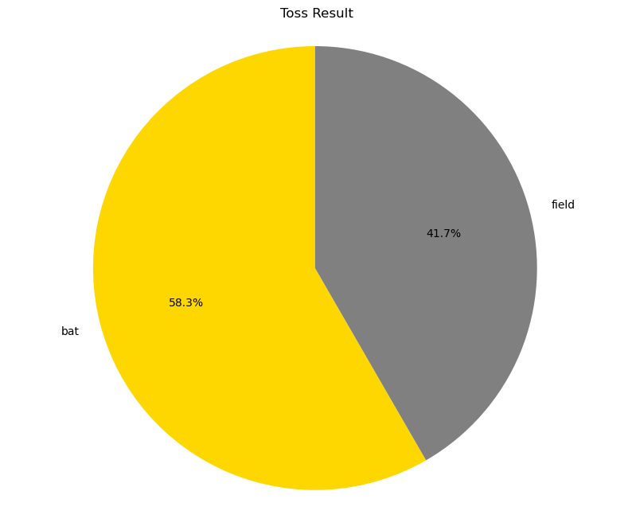

```python
Toss = champ.toss_decision.value_counts()
labels = np.array(Toss.index)
sizes = Toss.values
colors = ['Gold','grey']
plt.figure(figsize=(10,8))
plt.pie(sizes,labels = labels, colors = colors,
       autopct = '%1.1f%%',startangle=90)
plt.title('Toss Result')
plt.axis('equal')
plt.show()
```

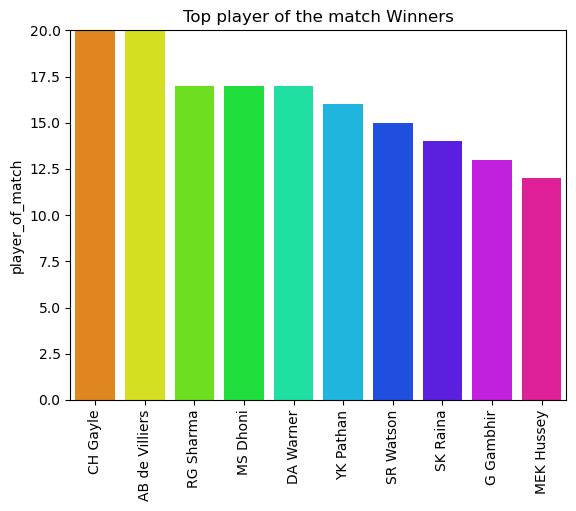

```python
# we will print name of top player in IPL
plt.figure(figsize = (18,10))
top_players = match_1.player_of_match.value_counts()[:10]
fig, ax = plt.subplots()
ax.set_ylim([0,20])
ax.set_ylabel("count")
ax.set_title("Top player of the match Winners")
top_players.plot.bar()
sns.barplot(x = top_players.index, y = top_players, orient='v', palette="hsv");
```

```python
champ.groupby(['city','winner']).size()
```

```
city          winner
Bangalore     Kolkata Knight Riders    1
              Sunrisers Hyderabad      1
Chennai       Chennai Super Kings      1
              Kolkata Knight Riders    1
Hyderabad     Mumbai Indians           2
Johannesburg  Deccan Chargers          1
Kolkata       Mumbai Indians           2
Mumbai        Chennai Super Kings      2
              Rajasthan Royals         1
dtype: int64
```

```python
champ['winner'].value_counts()
```

```
Mumbai Indians           4
Chennai Super Kings      3
Kolkata Knight Riders    2
Rajasthan Royals         1
Deccan Chargers          1
Sunrisers Hyderabad      1
Name: winner, dtype: int64
```

```python
champ[['toss_winner','toss_decision','winner']].reset_index(drop = True)
```

|  | toss_winner | toss_decision | winner |
| --- | --- | --- | --- |
| 0 | Mumbai Indians | bat | Mumbai Indians |
| 1 | Rajasthan Royals | field | Rajasthan Royals |
| 2 | Royal Challengers Bangalore | field | Deccan Chargers |
| 3 | Chennai Super Kings | bat | Chennai Super Kings |
| 4 | Chennai Super Kings | bat | Chennai Super Kings |
| 5 | Chennai Super Kings | bat | Kolkata Knight Riders |
| 6 | Mumbai Indians | bat | Mumbai Indians |
| 7 | Kolkata Knight Riders | field | Kolkata Knight Riders |
| 8 | Chennai Super Kings | field | Mumbai Indians |
| 9 | Sunrisers Hyderabad | bat | Sunrisers Hyderabad |
| 10 | Chennai Super Kings | field | Chennai Super Kings |
| 11 | Mumbai Indians | bat | Mumbai Indians |

```python
champ[['winner','player_of_match']].reset_index(drop = True)
```

|  | winner | player_of_match |
| --- | --- | --- |
| 0 | Mumbai Indians | KH Pandya |
| 1 | Rajasthan Royals | YK Pathan |
| 2 | Deccan Chargers | A Kumble |
| 3 | Chennai Super Kings | SK Raina |
| 4 | Chennai Super Kings | M Vijay |
| 5 | Kolkata Knight Riders | MS Bisla |
| 6 | Mumbai Indians | KA Pollard |
| 7 | Kolkata Knight Riders | MK Pandey |
| 8 | Mumbai Indians | RG Sharma |
| 9 | Sunrisers Hyderabad | BCJ Cutting |
| 10 | Chennai Super Kings | SR Watson |
| 11 | Mumbai Indians | JJ Bumrah |

```python
season_data=match_1[['id','season','winner']]
complete_data=deliveries.merge(season_data,how='inner',left_on='match_id',right_on='id')
```

```python
season_data
```

|  | id | season | winner |
| --- | --- | --- | --- |
| 0 | 1 | 2017 | Sunrisers Hyderabad |
| 1 | 2 | 2017 | Rising Pune Supergiant |
| 2 | 3 | 2017 | Kolkata Knight Riders |
| 3 | 4 | 2017 | Kings XI Punjab |
| 4 | 5 | 2017 | Royal Challengers Bangalore |
| ... | ... | ... | ... |
| 751 | 11347 | 2019 | Mumbai Indians |
| 752 | 11412 | 2019 | Mumbai Indians |
| 753 | 11413 | 2019 | Delhi Capitals |
| 754 | 11414 | 2019 | Chennai Super Kings |
| 755 | 11415 | 2019 | Mumbai Indians |

756 rows × 3 columns

```python
complete_data.info()
```

```
<class 'pandas.core.frame.DataFrame'>
Int64Index: 179078 entries, 0 to 179077
Data columns (total 24 columns):
 #   Column            Non-Null Count   Dtype
---  ------            --------------   -----
 0   match_id          179078 non-null  int64
 1   inning            179078 non-null  int64
 2   batting_team      179078 non-null  object
 3   bowling_team      179078 non-null  object
 4   over              179078 non-null  int64
 5   ball              179078 non-null  int64
 6   batsman           179078 non-null  object
 7   non_striker       179078 non-null  object
 8   bowler            179078 non-null  object
 9   is_super_over     179078 non-null  int64
```

[output cut: 16 more lines]

```python
fours = complete_data[complete_data['batsman_runs']==4]
fours.groupby('batting_team')['batsman_runs'].agg([('runs by fours','sum'),('fours','count')])
```

| batting_team | runs by fours | fours |
| --- | --- | --- |
| Chennai Super Kings | 8772 | 2193 |
| Deccan Chargers | 3828 | 957 |
| Delhi Capitals | 968 | 242 |
| Delhi Daredevils | 8632 | 2158 |
| Gujarat Lions | 1840 | 460 |
| Kings XI Punjab | 9832 | 2458 |
| Kochi Tuskers Kerala | 680 | 170 |
| Kolkata Knight Riders | 9736 | 2434 |
| Mumbai Indians | 10352 | 2588 |
| Pune Warriors | 2100 | 525 |
| Rajasthan Royals | 8140 | 2035 |
| Rising Pune Supergiant | 788 | 197 |
| Rising Pune Supergiants | 684 | 171 |
| Royal Challengers Bangalore | 9440 | 2360 |
| Sunrisers Hyderabad | 5776 | 1444 |

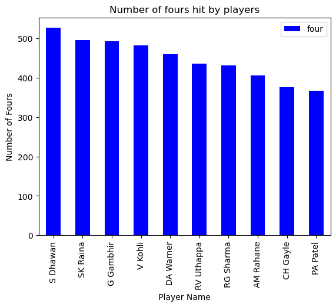

```python
#graph on four
four_by_batsman = fours.groupby('batsman')['batsman_runs'].agg([('four','count')]).reset_index().sort_values('four',ascending=0)
ax = four_by_batsman.iloc[:10,:].plot('batsman','four',kind = 'bar',color = 'blue')
plt.title('Number of fours hit by players')
plt.xticks(rotation = 'vertical')
plt.xlabel('Player Name')
plt.ylabel('Number of Fours')
plt.show()
```

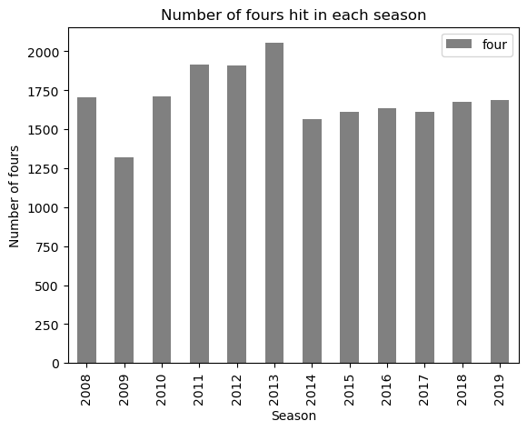

```python
#number of fours hit in each season
ax=fours.groupby('season')['batsman_runs'].agg([('four','count')]).reset_index().plot('season','four',kind='bar',color = 'grey')
plt.title('Number of fours hit in each season')
plt.xticks(rotation = 'vertical')
plt.ylabel('Number of fours')
plt.xlabel('Season')
plt.show()
```

```python
#No.of sixes
sixes = complete_data[complete_data['batsman_runs']==6]
sixes.groupby('batting_team')['batsman_runs'].agg([('runs by six','sum'),('sixes','count')])
```

| batting_team | runs by six | sixes |
| --- | --- | --- |
| Chennai Super Kings | 5838 | 973 |
| Deccan Chargers | 2400 | 400 |
| Delhi Capitals | 522 | 87 |
| Delhi Daredevils | 4806 | 801 |
| Gujarat Lions | 930 | 155 |
| Kings XI Punjab | 5856 | 976 |
| Kochi Tuskers Kerala | 318 | 53 |
| Kolkata Knight Riders | 5580 | 930 |
| Mumbai Indians | 6576 | 1096 |
| Pune Warriors | 1176 | 196 |
| Rajasthan Royals | 4086 | 681 |
| Rising Pune Supergiant | 534 | 89 |
| Rising Pune Supergiants | 408 | 68 |
| Royal Challengers Bangalore | 6792 | 1132 |
| Sunrisers Hyderabad | 3198 | 533 |

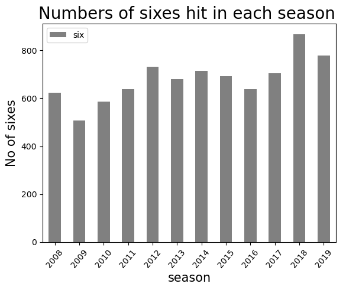

```python
#graph hit by players
ax=sixes.groupby('season')['batsman_runs'].agg([('six','count')]).reset_index().plot('season','six',kind='bar',color = 'grey')
plt.title("Numbers of sixes hit in each season ",fontsize=20)
plt.xticks(rotation=50)
plt.xlabel("season",fontsize=15)
plt.ylabel("No of sixes",fontsize=15)
plt.show()
```

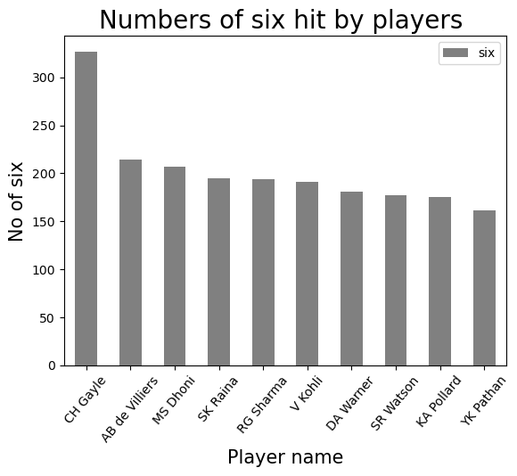

```python
# we will plot graph of six hit by players
six_batsman=sixes.groupby('batsman')['batsman_runs'].agg([('six','count')]).reset_index().sort_values('six',ascending=0)
ax=six_batsman.iloc[:10,:].plot('batsman','six',kind='bar',color='grey')
plt.title("Numbers of six hit by players ",fontsize=20)
plt.xticks(rotation=50)
plt.xlabel("Player name",fontsize=15)
plt.ylabel("No of six",fontsize=15)
plt.show()
```

```python
#top run scorer
batsman_score = deliveries.groupby('batsman')['batsman_runs'].agg(['sum']).reset_index().sort_values('sum',ascending=False).reset_index(drop=True)
batsman_score = batsman_score.rename(columns={'sum':'batsman_runs'})
print("*** Top 10 Leading Run Scorer in IPL ***")
batsman_score.iloc[:10,:]
```

```
*** Top 10 Leading Run Scorer in IPL ***
```

|  | batsman | batsman_runs |
| --- | --- | --- |
| 0 | V Kohli | 5434 |
| 1 | SK Raina | 5415 |
| 2 | RG Sharma | 4914 |
| 3 | DA Warner | 4741 |
| 4 | S Dhawan | 4632 |
| 5 | CH Gayle | 4560 |
| 6 | MS Dhoni | 4477 |
| 7 | RV Uthappa | 4446 |
| 8 | AB de Villiers | 4428 |
| 9 | G Gambhir | 4223 |

```python
#Number of matches played by batsman
Number_of_matches = deliveries[['match_id','player_dismissed']]
Number_of_matches = Number_of_matches.groupby("player_dismissed")["match_id"].count().reset_index().sort_values(by="match_id",ascending=False).reset_index(drop=True)
Number_of_matches.columns=["batsman","No_of Matches"]
Number_of_matches.head(5)
```

|  | batsman | No_of Matches |
| --- | --- | --- |
| 0 | SK Raina | 162 |
| 1 | RG Sharma | 155 |
| 2 | RV Uthappa | 153 |
| 3 | V Kohli | 143 |
| 4 | S Dhawan | 137 |

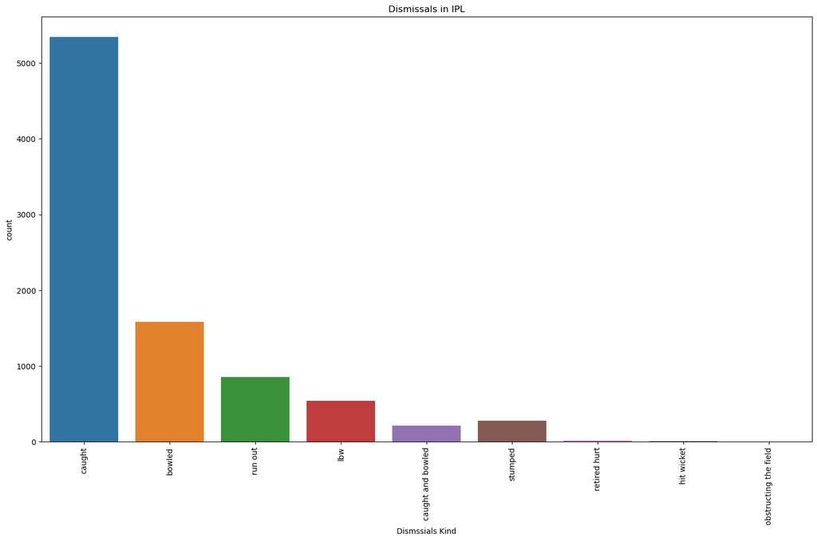

```python
#Number of Dismissals
plt.figure(figsize=(18,10))
ax = sns.countplot(deliveries.dismissal_kind)
plt.title('Dismissals in IPL')
plt.xlabel('Dismssials Kind')
plt.ylabel('count')
plt.xticks(rotation = 'vertical')
plt.show()
```

```python
wickets = deliveries.dropna(subset=['dismissal_kind'])
wickets = wickets[~wickets['dismissal_kind'].isin(['run out','retired hurt','obstructing the field'])]
```

```python
wickets.groupby('bowler')['dismissal_kind'].agg(['count']).reset_index().sort_values('count',ascending=False).reset_index(drop=True).iloc[:10,:]
```

|  | bowler | count |
| --- | --- | --- |
| 0 | SL Malinga | 170 |
| 1 | A Mishra | 156 |
| 2 | Harbhajan Singh | 150 |
| 3 | PP Chawla | 149 |
| 4 | DJ Bravo | 147 |
| 5 | B Kumar | 133 |
| 6 | R Ashwin | 125 |
| 7 | SP Narine | 122 |
| 8 | UT Yadav | 119 |
| 9 | RA Jadeja | 108 |

**Conclusion**

Mumbai Indians team won highest number of matches (4 out of 12 maatches).

Teams that chose bowling first has the higher chance of winning than teams that choose to bat first.

After winning toss, more teams choose to fielding first.

Top players of match were CH gayle, AB de villers.

Out of 12 final matches, the team that won the toss 9 times also won the IPL final.

Highest number of fours' were hit by player : Shikar Dhawan

Highest number of sixes were hit by player : CH Gayle

Top Scorers : Virat Kohli, SK Raina, RG Sharma

The highest number of matches were played by : SK RAina, RG Sharma

Dismissals was most by catch out.

Most Wickets were taken by SL Malinga.

By observing the above conclusions, we can observe that: **Most Successful Team** is **Mumbai Indians**

**Successful players** are **CH Gayle** and **SK Raina**

**Winning or losing the toss** and **choosing feilding or batting fisrt** contributes to the win or loss of the team.